# What makes a game popular?

In this project I want to find what qualities, or attributes coorelate to a game being popular. I will be using data taken from Steam, as they are the most dominant game distributer in the entire PC market. Steam also provides API's that makes it possible to keep detail track of game sales and popularity.

I found this dataset in Kaggle, that uses Steam's API to track game sales and more: https://www.kaggle.com/datasets/nikdavis/steam-store-games?select=steam.csv

Here are some tools, that I will be using for this project:

```python
import pandas as pd
import seaborn as sns
import matplotlib.pyplot as plt
```

Starting with the preprocessing, I had to drop a few irrelevant columns. Appid is basically the ID for each game/app, but I can't really do anything with that so I dropped it. Achivements, might in a way affect how a game is percieved but afterall I ended up dropping it. I also found median_playtime a bit redundant as I feel avarage_playtine sufices.

I founded way more helptful if I just grabbed a percentage of a games good ratings to form a game's score. Then I used formatted it into a percentage. Finally I drop both ratting columns as the score column basicallt did their jobs.

```python
df = pd.read_csv('steamcharts/steam.csv')
df.columns
df = df.drop(columns=['appid', 'achievements', 'median_playtime'])
df = df.dropna(subset=["positive_ratings"])
df = df.dropna(subset=["negative_ratings"])
df = df.dropna(subset=["owners", "developer"])
df = df.drop_duplicates('name')
rating_percentage = df['positive_ratings'] / (df['positive_ratings'] + df['negative_ratings'])
rating_percentage = rating_percentage.apply(lambda x: round(x * 100, 2))
rating_percentage = rating_percentage.fillna(0)
df['score'] = rating_percentage
df["english"] = df["english"].astype(bool)
df = df.drop(columns=['positive_ratings', 'negative_ratings'])
df = df.sort_values(by='owners', ascending=False)
df = df.reset_index(drop=True)
df
```

|  | name | release_date | english | developer | publisher | platforms | required_age | categories | genres | steamspy_tags | average_playtime | owners | price | score |
| --- | --- | --- | --- | --- | --- | --- | --- | --- | --- | --- | --- | --- | --- | --- |
| 0 | PLAYERUNKNOWN'S BATTLEGROUNDS | 12/21/2017 | True | PUBG Corporation | PUBG Corporation | windows | 0 | Multi-player;Online Multi-Player;Stats | Action;Adventure;Massively Multiplayer | Survival;Shooter;Multiplayer | 22938 | 50000000-100000000 | 26.99 | 50.46 |
| 1 | Counter-Strike: Global Offensive | 8/21/2012 | True | Valve;Hidden Path Entertainment | Valve | windows;mac;linux | 0 | Multi-player;Steam Achievements;Full controlle... | Action;Free to Play | FPS;Multiplayer;Shooter | 22494 | 50000000-100000000 | 0.00 | 86.80 |
| 2 | Infestation: The New Z | 11/22/2016 | True | Fredaikis AB | Fredaikis AB | windows | 0 | Online Multi-Player;MMO;Online Co-op;Steam Ach... | Action;Free to Play;Indie;Massively Multiplaye... | Zombies;Free to Play;Survival | 376 | 5000000-10000000 | 0.00 | 49.15 |
| 3 | Cities: Skylines | 3/10/2015 | True | Colossal Order Ltd. | Paradox Interactive | windows;mac;linux | 0 | Single-player;Steam Achievements;Steam Trading... | Simulation;Strategy | City Builder;Simulation;Building | 3225 | 5000000-10000000 | 22.99 | 91.84 |
| 4 | PlanetSide 2 | 11/20/2012 | True | Daybreak Game Company | Daybreak Game Company | windows | 0 | Multi-player;MMO;Steam Trading Cards | Action;Free to Play;Massively Multiplayer | Free to Play;Massively Multiplayer;FPS | 1051 | 5000000-10000000 | 0.00 | 82.27 |
| ... | ... | ... | ... | ... | ... | ... | ... | ... | ... | ... | ... | ... | ... | ... |
| 27027 | You Are God | 5/19/2017 | True | BefuddleBug | BefuddleBug | windows | 0 | Single-player | Indie;Simulation;Strategy;Early Access | Early Access;Strategy;Indie | 111 | 0-20000 | 3.99 | 25.00 |
| 27028 | Tales of Terror: Crimson Dawn | 3/1/2017 | True | Deep Shadows Games | Big Fish Games | windows | 0 | Single-player | Adventure;Casual | Casual;Adventure;Hidden Object | 0 | 0-20000 | 4.99 | 0.00 |
| 27029 | S-COPTER: Trials of Quick Fingers and Logic | 2/12/2018 | True | Noble Fox Games | Noble Fox Games | windows | 0 | Single-player;Local Multi-Player;Local Co-op;S... | Action;Indie | Action;Indie;Puzzle | 0 | 0-20000 | 5.79 | 100.00 |
| 27030 | Apocryph: an old-school shooter | 4/27/2018 | True | Bigzur Games | Bigzur Games | windows;linux | 0 | Single-player;Steam Achievements;Steam Trading... | Violent;Gore;Action;Adventure;Indie | Action;Gore;Adventure | 0 | 0-20000 | 11.39 | 60.00 |
| 27031 | Rune Lord | 4/24/2019 | True | Adept Studios GD | Alawar Entertainment | windows;mac | 0 | Single-player;Steam Cloud | Adventure;Casual;Indie | Indie;Casual;Adventure | 0 | 0-20000 | 5.19 | 100.00 |

27032 rows × 14 columns

I want to visualize the relation of game score to overall ownership of the game. I will filter the database based on the games with the top ownership. Then based on the score I will catagorize, the scores into general reception and create a pie chart off of it. Pie charts, Is an effective way to show the percentage of catagorical data from the whole.

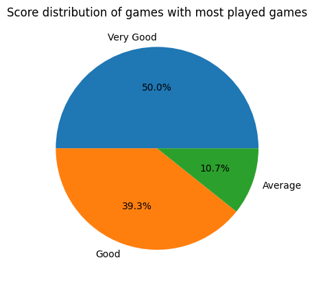

```python
top = df[df["owners"].isin(["50000000-100000000", "5000000-10000000"])]
top["score"] = pd.to_numeric(top["score"], errors="coerce")
top = top.dropna(subset=["score"])
def lable(lbl):
    if lbl > 0 and lbl <= 20:
        return "Very Poor"
    elif lbl <= 40:
        return "Poor"
    elif lbl <= 60:
        return "Average"
    elif lbl <= 80:
        return "Good"
    elif lbl <= 90:
        return "Very Good"
    return None
top["reception"] = top["score"].apply(lable)
top = top.dropna(subset=["reception"])
counts = top["reception"].value_counts()
counts = top["reception"].value_counts()
plt.pie(counts, labels=counts.index, autopct=lambda pct: '{:.1f}%'.format(pct) if pct > 0 else '')
plt.title("Score distribution of games with most played games")
plt.show()
```